## Assignment 7

#### Due Sunday, April 2, 11:59 PM CT

### Preliminaries

- Directories
  - COURSE/homework/
  - COURSE/homework/hw07/
  - COURSE/data/
  - COURSE/scripts/
- Files
  - COURSE/homework/hw07/hw07.Rmd
  - COURSE/scripts/viridis.R
  - COURSE/scripts/ggprob.R

### Aims

- Practice probability and the binomial distribution

### Problems

1. A discrete random variable $X$ has possible values 0, 1, 2, 3, 4, 5, 6, 7, 8 with the following partial probability distribution. The missing probabilities $\mathsf{P}(X=7)$ and $\mathsf{P}(X=8)$ are equal to each other.

| x | 0 | 1 | 2 | 3 | 4 | 5 | 6 | 7 | 8 |
| --- | --- | --- | --- | --- | --- | --- | --- | --- | --- |
| P(X=x) | 0.04 | 0.06 | 0.11 | 0.12 | 0.14 | 0.17 | 0.2 | NA | NA |

- Put the values `x = 0:8` and the tabled probabilities `p` into a data frame (use `tibble()`).

```r
p1_tab
```

```
## # A tibble: 1 × 10
##   x        `0`   `1`   `2`   `3`   `4`   `5`   `6`   `7`   `8`
##   <chr>  <dbl> <dbl> <dbl> <dbl> <dbl> <dbl> <dbl> <dbl> <dbl>
## 1 P(X=x)  0.04  0.06  0.11  0.12  0.14  0.17   0.2    NA    NA
```

```r
x
```

```
## [1] 0 1 2 3 4 5 6 7 8
```

```r
p
```

```
## [1] 0.04 0.06 0.11 0.12 0.14 0.17 0.20
```

```r
p1
```

```
## # A tibble: 9 × 2
##       x     p
##   <int> <dbl>
## 1     0  0.04
## 2     1  0.06
## 3     2  0.11
## 4     3  0.12
## 5     4  0.14
## 6     5  0.17
## 7     6  0.2
## 8     7 NA
## 9     8 NA
```

```r
#q1_tibble=tibble(x,p1_tab$p)

#anohter way to use p1 directly
q1_tibble=p1
q1_tibble
```

```
## # A tibble: 9 × 2
##       x     p
##   <int> <dbl>
## 1     0  0.04
## 2     1  0.06
## 3     2  0.11
## 4     3  0.12
## 5     4  0.14
## 6     5  0.17
## 7     6  0.2
## 8     7 NA
## 9     8 NA
```

```r
#another way to change the already formed tibble into the new tibble
#p1_tab_longer
#q1_tibble=as_tibble()
#make the sum and take half and store in the  values which are NA

#verification
#get hte sum of probabilities

#%>% summarize(sum=sum(p)) %>% pull(sum))
```

- Write code to calculate the missing values for $\mathsf{P}(X=7) = \mathsf{P}(X = 8)$ and replace the missing values with these calculated values into your data frame.

```r
sum=q1_tibble %>% filter(x!=7 & x!=8) %>% summarize(sum=sum(p)) %>% pull(sum)
sum
```

```
## [1] 0.84
```

```r
q1_tibble<-q1_tibble %>% mutate(p=case_when((x==7|x==8)~(1-sum)/2,TRUE~p))
q1_tibble
```

```
## # A tibble: 9 × 2
##       x      p
##   <int>  <dbl>
## 1     0 0.04
## 2     1 0.06
## 3     2 0.11
## 4     3 0.12
## 5     4 0.14
## 6     5 0.17
## 7     6 0.2
## 8     7 0.0800
## 9     8 0.0800
```

- Verify that the sum of all probabilities is 1.

```r
q1_tibble %>% summarize(sum=sum(p))
```

```
## # A tibble: 1 × 1
##     sum
##   <dbl>
## 1     1
```

- Calculate the mean, variance, and standard deviation of this distribution.

```r
#weighted mean=sum of product of all the x*p values
stats_final=q1_tibble %>% mutate(mean=x*p,variance=((x-mean)^2)*p,sigma=sqrt(variance)) %>% summarize(mean_final=sum(mean),variance_final=sum(variance),sigma_final=sum(sigma))
stats_final
```

```
## # A tibble: 1 × 3
##   mean_final variance_final sigma_final
##        <dbl>          <dbl>       <dbl>
## 1       4.45           18.1        10.8
```

2. Suppose you have a random variable $X \sim \text{Binomial}(120, 0.2)$.
- 2a. Calculate and report the mean and standard deviation of the distribution.

```r
n=120
p=0.2
x=rbinom(n,n,p)
#ASK:WHAT SHOULD WE GIVE AS THE FIRST ARGUMENT TO THE ABOVE METHOD-NO NUMBER OF DATA POINTS TO BE TAKEN IS SPECIFIED
x=data.frame(x)
x %>% summarize(mean=n*p,sigma=sqrt(mean*(1-p)))
```

```
##   mean   sigma
## 1   24 4.38178
```

```r
#print(mean=n*p,sigma=sqrt(120*0.2*0.8))
```

- 2b. Calculate and report the probability that the random variable is exactly equal to 20, $\mathsf{P}(X = 20)$.

```r
#get p(<=20)-p(<=19) to get p(20)
x
```

[output not shown]

[output cut: 106 more lines]

```r
print(dbinom(20,n,p))
```

```
## [1] 0.06293094
```

```r
print(pbinom(20,n,p)-pbinom(19,n,p))#do for <=20-<=19
```

```
## [1] 0.06293094
```

- 2c. Calculate and report the probability that $X$ equals 20 or more, $\mathsf{P}(X \ge 20)$.

```r
print(1-pbinom(19,n,p))
```

```
## [1] 0.8482865
```

- 2d. Draw a graph of the binomial distribution with vertical lines at the mean (red and dashed), and 1, 2, and 3 standard deviations above and below the mean (red and dotted).

```r
#MAKE A GRAPH BY GBINOM AND THEN USE C() TO GET -1,+1 AND 02,+2 AND -3,+3 AT SD VALUES
x1=x$mean
x1
```

[output not shown]

```r
mean1=n*p
variance1=mean1*(1-p)
variance1
```

```
## [1] 19.2
```

```r
sigma1=sqrt(variance1)
sigma1
```

```
## [1] 4.38178
```

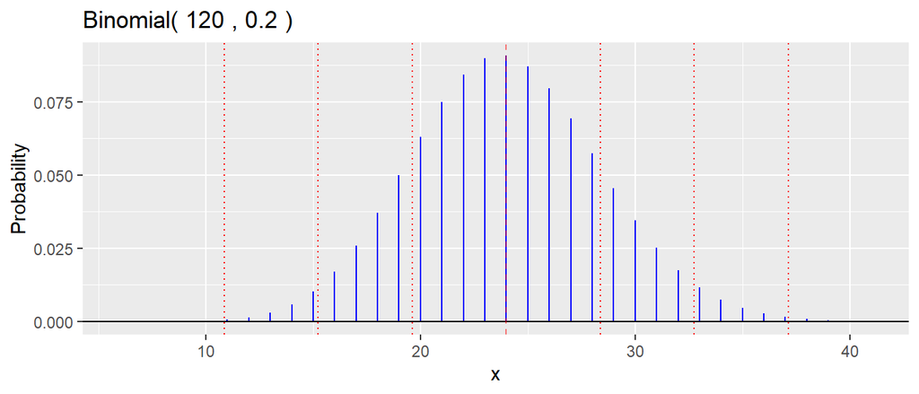

```r
gbinom(n,p,scale=TRUE)+ geom_vline(xintercept=mean1,linetype="dashed",color="red",alpha=0.5)+geom_vline(xintercept=c(-1,1)*sigma1+mean1,linetype="dotted",color="red")+geom_vline(xintercept=c(-2,2)*sigma1+mean1,linetype="dotted",color="red")+geom_vline(xintercept=c(-3,3)*sigma1+mean1,linetype="dotted",color="red")
```

3. What is the probability that $X$ from Problem 2 is within one, two, and three standard deviations of the mean? Round each probability to four decimal places.

```r
#patern:
#print->format->round+nsmall
print(format(round((pbinom(sigma1+mean1,n,p)-pbinom(-sigma1+mean1,n,p)),4),nsmall=4))
```

```
## [1] "0.6960"
```

```r
#print(pbinom(sigma1+mean1,n,p)-pbinom(-sigma1+mean1,n,p))
print(format(round((pbinom(mean1+(2*sigma1),n,p)-pbinom(mean1-(2*sigma1),n,p)),4),nsmall=4))
```

```
## [1] "0.9486"
```

```r
#print(pbinom(2*sigma1*mean1,n,p)-pbinom(sigma1*-2*mean1,n,p))
#print(pbinom((3*sigma1)+mean1,n,p)-pbinom(-(3*sigma1)+mean1,n,p))
print(format(round((pbinom(mean1+(3*sigma1),n,p)-pbinom(mean1-(3*sigma1),n,p)),4),nsmall=4))
```

```
## [1] "0.9979"
```

```r
#ASK:LAST ANSWER GIVING WRONG ANSWER-WE SHOULD GET 0.0000 BUT GETTING 1.0000
```

Probability of being at 1 sd from the mean=0.6960 Probability of being at 2nd sd from the mean=0.9486 Probability of being at 3rd sd from the mean=0.9979

4. The following code makes a graph of the cumulative distribution function for the $\text{Binomial}(7, 0.3)$ distribution, that is $F(x) = \mathsf{P}(X \le x)$. This is the function which is calculated by the base R function `pbinom()`.
- Modify the code to add a horizontal red dotted line at 0.4.

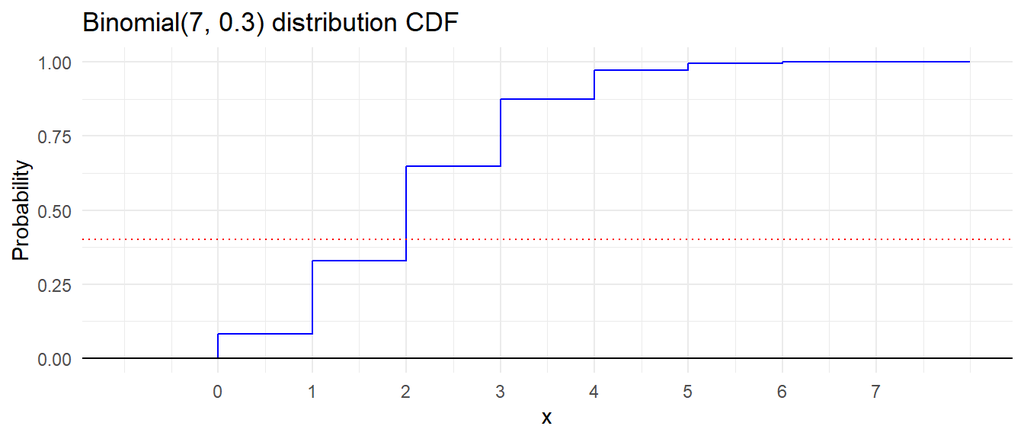

```r
prob4 = tibble(
  x = seq(-1,8,1),
  p = dbinom(x, 7, 0.3),
  cdf = pbinom(x, 7, 0.3))

ggplot(prob4, aes(x = x, y = cdf )) +
  geom_step(color = "blue") +
  geom_hline(yintercept = 0) +geom_hline(yintercept=0.4,linetype="dotted",color="red")+
  scale_x_continuous(breaks = 0:7) +
  xlab("x") +
  ylab("Probability") +
  ggtitle("Binomial(7, 0.3) distribution CDF") +
  theme_minimal()
```

- Calculate the 0.4 quantile of the $\text{Binomial}(7, 0.3)$

```r
print(qbinom(0.4,7,0.3))
```

```
## [1] 2
```

- Explain how the value of the quantile is related to the red dotted line which you added to the plot.

> the quantile x=2 is crossed by the red dotted line at value 0.4 thus x=2 is the 40th percentile of the distribution
- Use the graph to determine the 0.75 quantile of this distribution. Then verify your observation with a calculation.

```r
print(qbinom(0.75,7,0.3))
```

```
## [1] 3
```

```r
print(qbinom(0.25,7,0.3))
```

```
## [1] 1
```

```r
print(qbinom(0.5,7,0.3))
```

```
## [1] 2
```

if the 0.4 quantile is at 2 then the 0.75 can be around 2.8-3.2 at my best guess as i presume that the middle 0.5 quantile might be somewhere around 2.1

5. In a large population of likely voters, the proportion of voters who plan to vote for candidate A is $p = 0.52$. In a random sample of 600 likely voters, what is the probability that the proportion of voters who plan to vote for candidate A is less than 50% (the number of such voters is less than 300)?

```r
n2=600
p2=0.52
print(pbinom((n2/2)-1,n2,p2))
```

```
## [1] 0.1535275
```

6. Basketball player 1 makes 80% of their free throws and basketball players 2 makes 70% of their free throws. Assume all of their free throws attempts are independent. If each player takes ten free throws and $X$ is the total number of free throws they make, does $X$ have a binomial distribution? If yes, specify the parameters $n$ and $p$. If not, explain why not.

> both the probability of getting a free throw good and the number of trials conducted are independent of both the players or the outcome of previous throws’ results. the probability of gettting a hit is always the same and so the variable x has a binomial distribution here x is defined for one single player and so the values of x for both the players is 10 and value of p for player 1 is 0.8 while for player 2 is 0.7
7. What is the smallest number of coin tosses $n$ of a fair coin so that the chance of getting 50 or more heads exceeds 90%? (You may need to do some trial and error. Alternatively, think of creating a data frame with a column `n` and a column for the probability and using this to find the answer.)

```r
p=0.5
trials=as.data.frame(x=1-pbinom(49,1:1000,p))
quest_tibble=data.frame(tibble(n=1:1000))
#to get >=50 w get <=49 and then subtract this from 1
quest_tibble<-quest_tibble %>% mutate(p1=1-pbinom(49,n,p)) %>% filter(p1>=0.9)
print(quest_tibble %>% slice_min(n) %>% select(n))
```

```
##     n
## 1 113
```

```r
trials
```

[output not shown]

[output cut: 986 more lines]

8. The random variable $X$ has the $\text{Binomial}(100, 0.2)$ distribution.
- Find an integer $a$ so that $P(X \le a) \ge 0.5$ and $P(X \ge a) \ge 0.5$.
- Show the values of $a$, $P(X \le a)$, and $P(X \ge a)$.

```r
quest8=data.frame(tibble(a=1:1000))
quest8<-quest8 %>% mutate(left_side=pbinom(a,100,0.2),right_side=1-pbinom(a-1,100,0.2))
#filter(left_side==right_side)
print(quest8 %>% filter(left_side>=0.5 & right_side>=0.5))
```

```
##    a left_side right_side
## 1 20 0.5594616  0.5398386
```

```r
#ASK:TO GET THE RIGHT PART WE DO A-1 AS WE WANT TO INCLUDE THE MIDDLE VALUE AGAIN
```